# Challenger Notebook

The mathematics of logistic regression.

Here we define $P(x, \beta)$.

$$\begin{align}
P(Y=1 | X=x, \beta)
&= \frac{exp(\beta_0 + \beta_1 x_1 + ...)}{1 + exp(\beta_0 + \beta_1 x_1 + ...)} \\
&= \frac{exp(\beta^T x)}{1+ exp(\beta^T x)} \\
&= P(x, \beta)
\end{align}$$

$$\begin{align}
odds
&= \frac{P(Y = 1 | x, \beta)}{P(Y = 0 | x, \beta)} \\
&= \frac{P(x, \beta)}{1-P(x, \beta)} \\
&= exp(\beta^T x)
\end{align}$$

What is happening lol

$$log(odds) = \beta^T x = \beta_0 + \beta_1 x + ...$$

Likelihood function and Log-likelihood function.

$$\begin{align}
L(\beta)
&= \Pi_{i=1}^n P(x_i, \beta)^{y_i} (1-P(x_i,\beta))^{1-y_i}
&\\
LL(\beta) &= logL(\beta) \\
& = \Sigma_{i=1}^{n}
[y_i \cdot log(P(x_i, \beta))
+ (1 - y_i) \cdot log(1-P(x_i, \beta)) ] \\
& = \Sigma_{i=1}^{n}
[y_i \beta^T x_i
- y_i \cdot log(1+exp(\beta^T x)
- (1 - y_i) \cdot log(1+exp(\beta^T x) ] \\
&= \Sigma_{i=1}^{n} [y_i \beta^T x_i - log(1+exp(\beta^T x))]
\end{align}$$

We are tasked to maximise the likelihood w.r.t. $\beta$

$$\frac{\delta LL(\beta)}{\delta \beta} = 0$$

Quality of fit

Null deviance Deviance of model with just intercept: $-2LL(\beta_0)$

Residual deviance Deviance for fitted model: $-2LL(\beta)$

$AIC = -2LL(\beta) + 2(p+1)$ which penalises extra parameters.

The dataset consists of 144 observations of 5 variables consisting of:  
Flight: name of flight; Date (date of flight);  
Field (1 if an Oring fails and 0 otherwise);  
Temp (Temperature in degrees Fahrenheit);  
Pres (Leak check pressure in psi).  
Each flight had 6 orings.

```r
orings <- read.csv("w3c1-challenger.csv")
str(orings)
```

```
'data.frame':   144 obs. of  5 variables:
 $ Flight: Factor w/ 24 levels "1","2","3","41-B",..: 1 1 1 1 1 1 2 2 2 2 ...
 $ Date  : Factor w/ 24 levels "1/12/1986","1/24/1985",..: 14 14 14 14 14 14 8 8 8 8 ...
 $ Field : int  0 0 0 0 0 0 1 0 0 0 ...
 $ Temp  : int  66 66 66 66 66 66 70 70 70 70 ...
 $ Pres  : int  50 50 50 50 50 50 50 50 50 50 ...
```

```r
summary(orings)
```

```
     Flight            Date         Field              Temp
 1      :  6   1/12/1986 :  6   Min.   :0.00000   Min.   :31.00
 2      :  6   1/24/1985 :  6   1st Qu.:0.00000   1st Qu.:66.75
 3      :  6   1/28/1986 :  6   Median :0.00000   Median :70.00
 41-B   :  6   10/3/1985 :  6   Mean   :0.07246   Mean   :67.96
 41-C   :  6   10/30/1985:  6   3rd Qu.:0.00000   3rd Qu.:75.00
 41-D   :  6   10/5/1984 :  6   Max.   :1.00000   Max.   :81.00
 (Other):108   (Other)   :108   NA's   :6
      Pres
 Min.   : 50.0
 1st Qu.: 87.5
 Median :200.0
 Mean   :154.2
 3rd Qu.:200.0
 Max.   :200.0
```

We plot the successes/failures and temperatures.  
We use jitter plot to randomly perturb points by a small amount to see the points that lie on top of each other better.

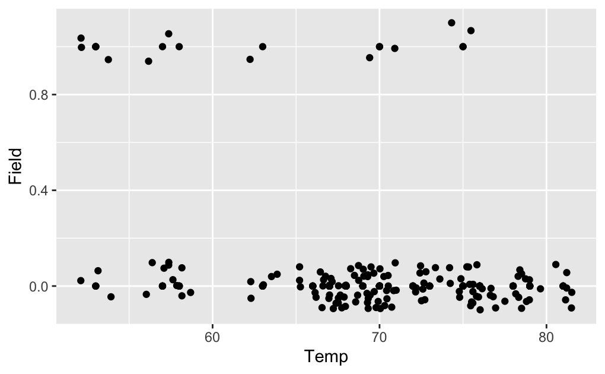

```r
library("ggplot2")
ggplot(orings[orings$Field>=0,],aes(Temp,Field)) +
  geom_point(na.rm=T) +
  geom_jitter(na.rm=T,width=1,height=0.1)
```

Fitting a iinear regression model

```r
model1 <- lm(Field~Temp+Pres,data=orings)
summary(model1)
```

```
Call:
lm(formula = Field ~ Temp + Pres, data = orings)

Residuals:
     Min       1Q   Median       3Q      Max
-0.27680 -0.09548 -0.03457 -0.00874  0.99126

Coefficients:
              Estimate Std. Error t value Pr(>|t|)
(Intercept)  0.7264305  0.2181384   3.330  0.00112 **
Temp        -0.0106657  0.0030704  -3.474  0.00069 ***
Pres         0.0005783  0.0003176   1.821  0.07088 .
---
Signif. codes:  0 ‘***’ 0.001 ‘**’ 0.01 ‘*’ 0.05 ‘.’ 0.1 ‘ ’ 1

Residual standard error: 0.2487 on 135 degrees of freedom
  (6 observations deleted due to missingness)
Multiple R-squared:  0.09941,   Adjusted R-squared:  0.08607
F-statistic: 7.451 on 2 and 135 DF,  p-value: 0.0008524
```

Now we use only Temperature

```r
model2 <- lm(Field~Temp,data=orings)
summary(model2)
```

```
Call:
lm(formula = Field ~ Temp, data = orings)

Residuals:
     Min       1Q   Median       3Q      Max
-0.24546 -0.09925 -0.06792 -0.00526  0.98429

Coefficients:
             Estimate Std. Error t value Pr(>|t|)
(Intercept)  0.798942   0.216289   3.694 0.000319 ***
Temp        -0.010443   0.003094  -3.375 0.000961 ***
---
Signif. codes:  0 ‘***’ 0.001 ‘**’ 0.01 ‘*’ 0.05 ‘.’ 0.1 ‘ ’ 1

Residual standard error: 0.2509 on 136 degrees of freedom
  (6 observations deleted due to missingness)
Multiple R-squared:  0.0773,    Adjusted R-squared:  0.07051
F-statistic: 11.39 on 1 and 136 DF,  p-value: 0.0009612
```

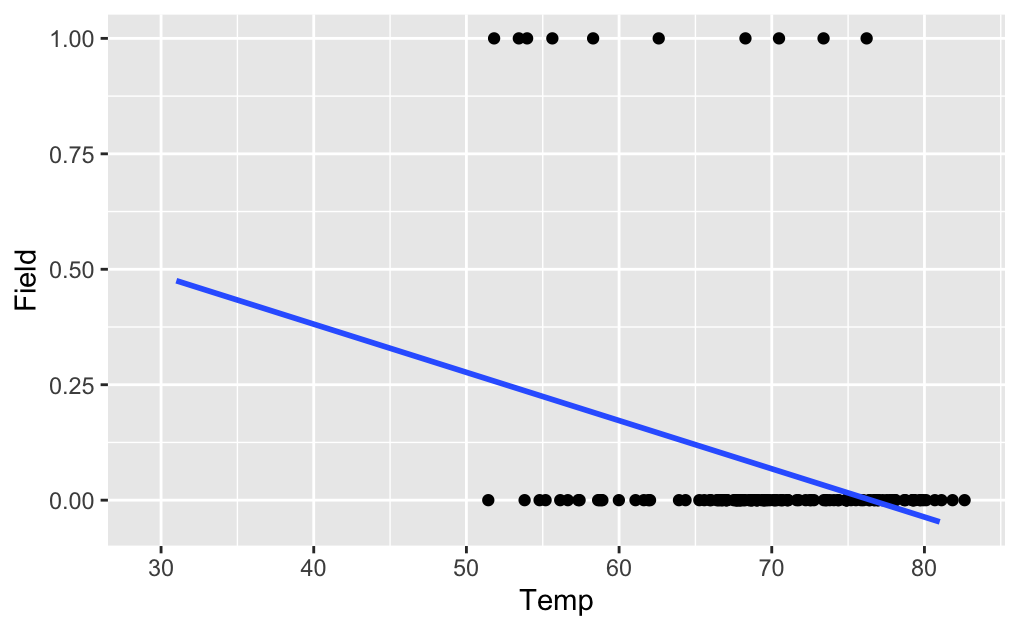

```r
ggplot(orings,aes(Temp,Field)) + geom_jitter(na.rm=T,height=0,width=2) + geom_smooth(method="lm",se=F,na.rm=T,fullrange=T)
```

The result indicates that the linear fit is not particularly convincing with a small value of R-squared, though it does identify that temperature has a significant effect and it is a negative impact.

Fitting a logistic regression model: glm() is a generalized linear model that can be used to fit a logistic regression model by choosing family=binomial.

```r
model3 <- glm(Field~Temp+Pres,data=orings,family=binomial)
summary(model3)
```

```
Call:
glm(formula = Field ~ Temp + Pres, family = binomial, data = orings)

Deviance Residuals:
    Min       1Q   Median       3Q      Max
-0.9243  -0.3680  -0.2432  -0.2059   2.8217

Coefficients:
             Estimate Std. Error z value Pr(>|z|)
(Intercept)  3.958071   3.497847   1.132  0.25781
Temp        -0.119355   0.044945  -2.656  0.00792 **
Pres         0.008692   0.007689   1.130  0.25829
---
Signif. codes:  0 ‘***’ 0.001 ‘**’ 0.01 ‘*’ 0.05 ‘.’ 0.1 ‘ ’ 1

(Dispersion parameter for binomial family taken to be 1)

    Null deviance: 71.751  on 137  degrees of freedom
Residual deviance: 60.470  on 135  degrees of freedom
  (6 observations deleted due to missingness)
AIC: 66.47

Number of Fisher Scoring iterations: 6
```

Now we use only temperature

```r
model4 <- glm(Field~Temp,data=orings,family=binomial)
summary(model4)
```

```
Call:
glm(formula = Field ~ Temp, family = binomial, data = orings)

Deviance Residuals:
    Min       1Q   Median       3Q      Max
-0.9155  -0.3770  -0.3075  -0.2036   2.7387

Coefficients:
            Estimate Std. Error z value Pr(>|z|)
(Intercept)  6.75183    2.97991   2.266  0.02346 *
Temp        -0.13971    0.04647  -3.007  0.00264 **
---
Signif. codes:  0 ‘***’ 0.001 ‘**’ 0.01 ‘*’ 0.05 ‘.’ 0.1 ‘ ’ 1

(Dispersion parameter for binomial family taken to be 1)

    Null deviance: 71.751  on 137  degrees of freedom
Residual deviance: 62.083  on 136  degrees of freedom
  (6 observations deleted due to missingness)
AIC: 66.083

Number of Fisher Scoring iterations: 6
```

```r
model3$coefficients
```

```
 (Intercept)         Temp         Pres
 3.958070598 -0.119355166  0.008691799
```

```r
model3$aic
```

```
[1] 66.4705
```

Model 3 describes  
$Prob(Fail = 1) = exp(3.95-0.119 Temp + 0.008 Pres)/(1+exp(3.95-0.119Temp+0.008Pres)).$  
The result indicates that Temp is significant at the 5% level.

```r
model4$coefficients
```

```
(Intercept)        Temp
  6.7518341  -0.1397096
```

```r
model4$aic
```

```
[1] 66.08252
```

Model 4 has a fit given by  
$P(Fail=1) = exp(6.75-0.1397Temp)/(1+exp(6.75-0.1397Temp))$.  
In terms of AIC (choose lower), Model 4 is preferred to Model 3. We drop the pressure variable in this example

Predictions:

```r
predict(model4, newdata = orings[144,]) # predicts on log(odds) scale
```

```
     144
2.420837
```

```r
predict(model4, newdata = orings[144,], type="response")
```

```
      144
0.9184025
```

There is a very high probabilty of failure.

Plots

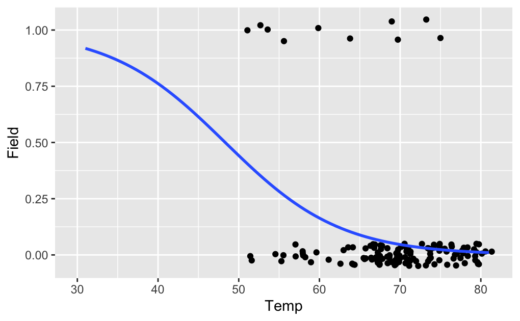

```r
ggplot(orings,aes(Temp,Field)) +
  geom_jitter(na.rm=T,height=0.05,width=2) +
  geom_smooth(method="glm",se=F,na.rm=T,fullrange=T,
              method.args = list(family = "binomial"))
```

Developing a predictive rule (classifier) and tabulating confusion matrices.  
Here we are still evaluating this with the training data. Typically we will use a test data to check on the results.

```r
Pred <- predict(model4,newdata=orings,type="response")
table(Pred[1:138]>0.5,orings$Field[1:138])
```

```
          0   1
  FALSE 128  10
```

```r
table(Pred[1:138]>0.3,orings$Field[1:138])
```

```
          0   1
  FALSE 125   7
  TRUE    3   3
```

```r
table(Pred[1:138]>0.1,orings$Field[1:138])
```

```
          0   1
  FALSE 110   4
  TRUE   18   6
```

The ROCR package is useful for visualizing the performance of classifier. The prediction function transforms the data to a standardized format and the performance function is used to do all kinds of prediction evaluations.

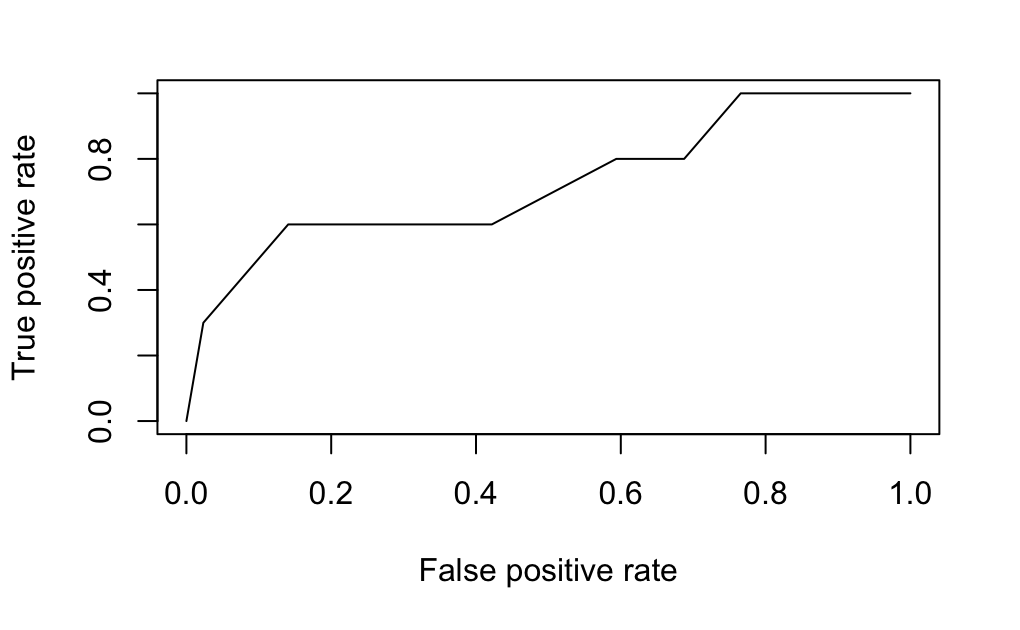

```r
#install.packages("ROCR")
library(ROCR)
ROCRpred <- prediction(Pred[1:138],orings$Field[1:138])
?performance
ROCRperf <- performance(ROCRpred,x.measure="fpr",measure="tpr")
plot(ROCRperf)
```

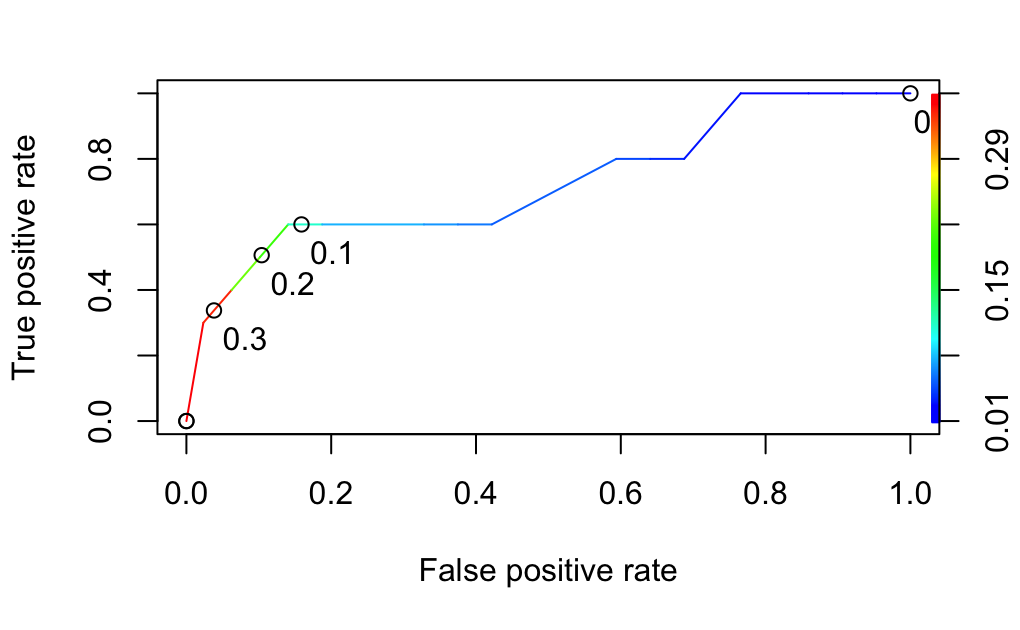

```r
plot(ROCRperf, colorize=T,print.cutoffs.at=c(0,0.1,0.2,0.3,0.5,1), text.adj=c(-0.2,1.7))
```

```r
performance(ROCRpred,measure="auc")
```

```
An object of class "performance"
Slot "x.name":
[1] "None"

Slot "y.name":
[1] "Area under the ROC curve"

Slot "alpha.name":
[1] "none"

Slot "x.values":
list()

Slot "y.values":
[[1]]
[1] 0.725


Slot "alpha.values":
list()
```

The AUC for this example is 0.725